# Wrangle Report

## 1 Intro

Here, we will briefly highlight particular topics tackled during the wrangling process that we have applied in `wrangle_act.ipynb` and document additional tests that have been performed but are not part of the 'data wrangling' process itself.

## 2 Gather

We have gathered data in the following ways:

- Tweet Data from `twitter_archive_enhanced.csv`;
- API Data from `tweet_json.txt` - (no API key available; no answer from Twitter concerning the developer account request);
- Image Predictions from Requests' HTTPS request.

Notes follow (2.1 to 2.3).

### 2.1 Trim Postponed

Right after having imported the 'twitter_archive_enhanced.csv', I have thought of filtering out tweets that do not meet the 'key-point' specifications - $i.e.$:

- You only want original ratings (no retweets)...
- ...that have images.
- You do not need to gather the tweets beyond August $1^{st}$, 2017.

However, I have decided to postpone these operations to the 'Cleaning' stage, for this step would require both, an assessment and a manipulation of the datasets.

### 2.2 JSON Data Load into a Pandas Data Frame

I have noticed that data types are processed differently if JSON data are imported via `json.loads` method or by using Pandas' `read_json` method.

In particular, I have tried to import the file `tweet_json.txt` in two ways:

1. By opening the file, transforming each JSON object in a dictionary, and adding it singularly into the target Pandas data frame ( DS['api'], as in wrangle_act.ipynb);
2. By importing the whole file directly with Pandas' `read_json` method (api_bkp).

For each of them, I have achieved the following results.

- Documentation for 1.:

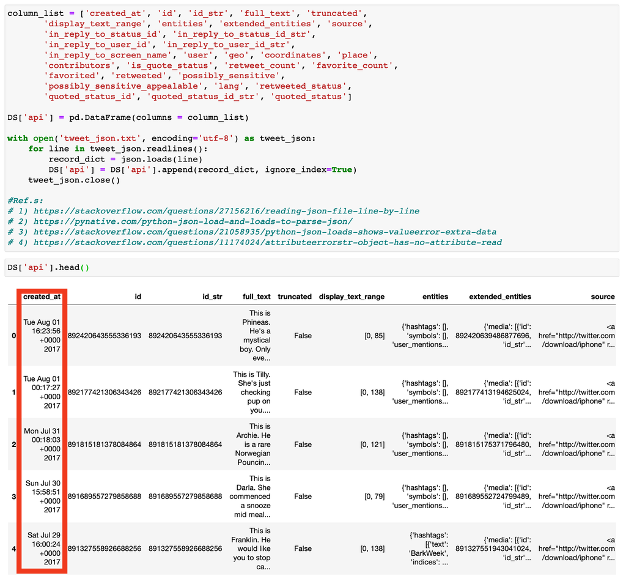

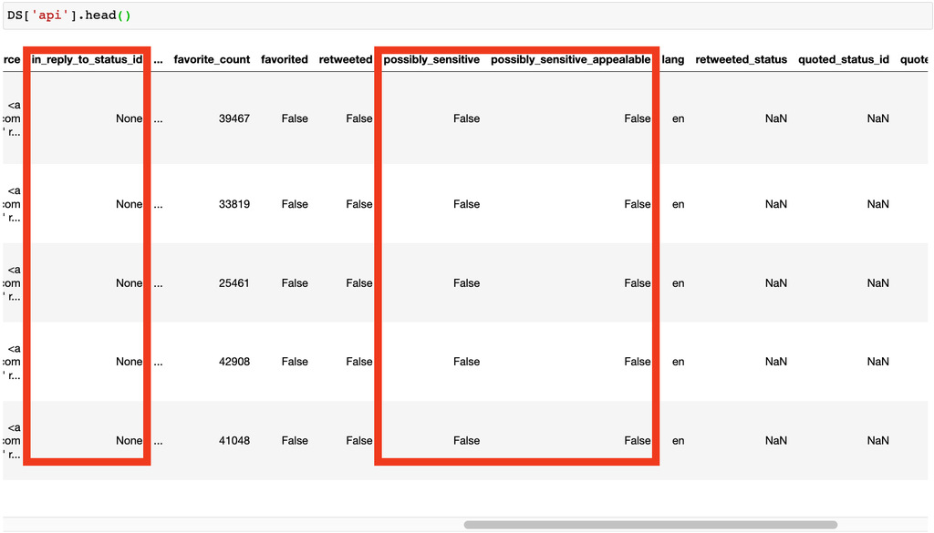

- Documentation for 2.:

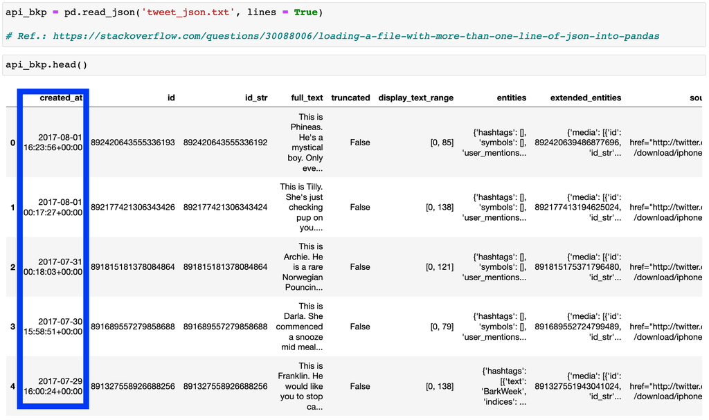

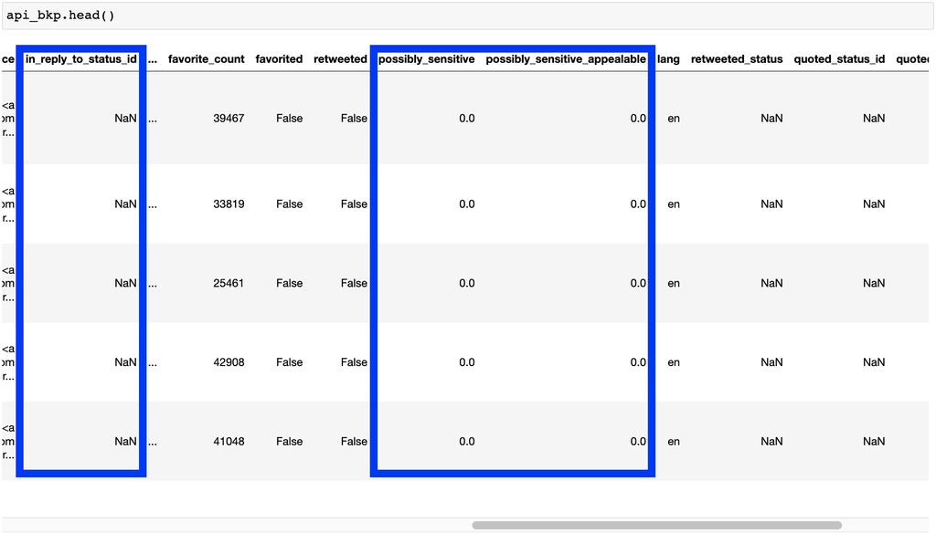

- DTypes Comparison

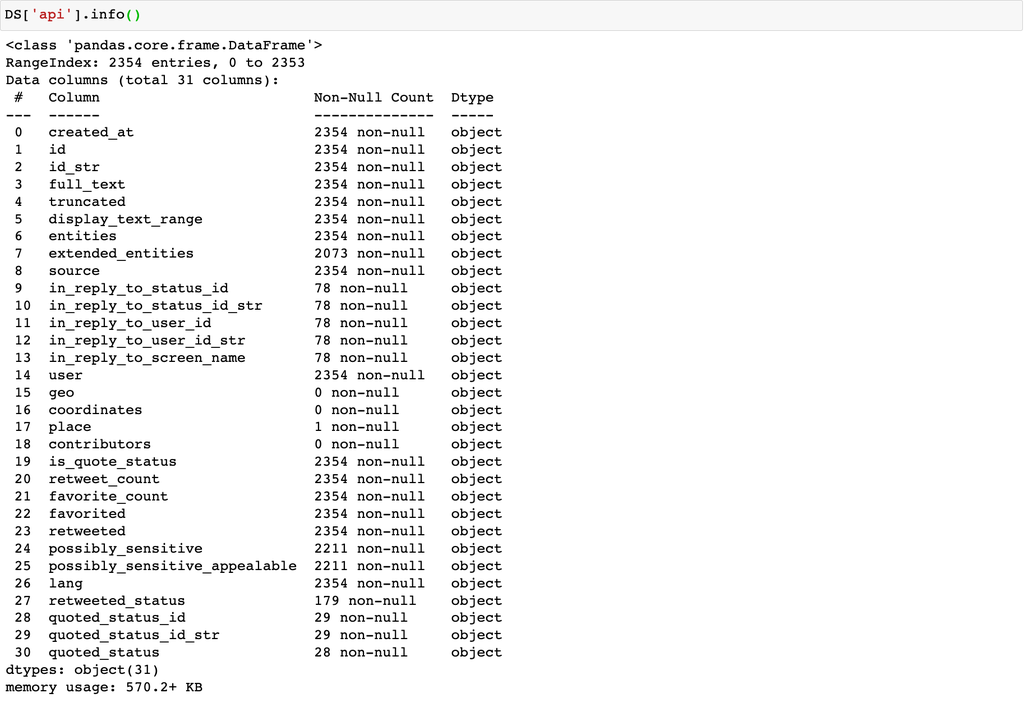

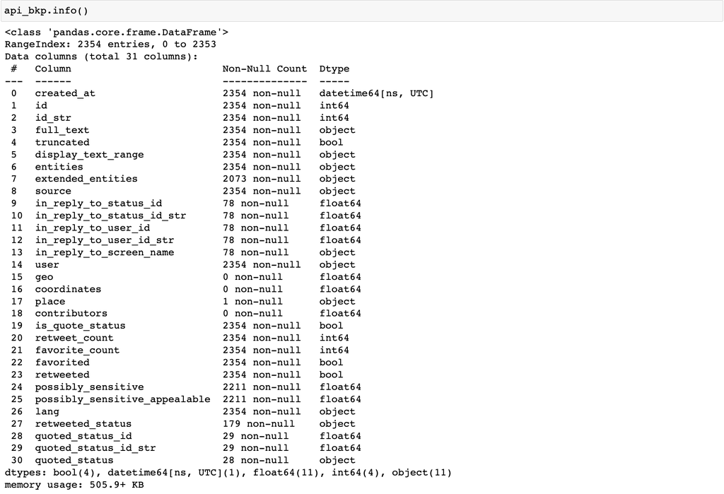

- Non-matching Records

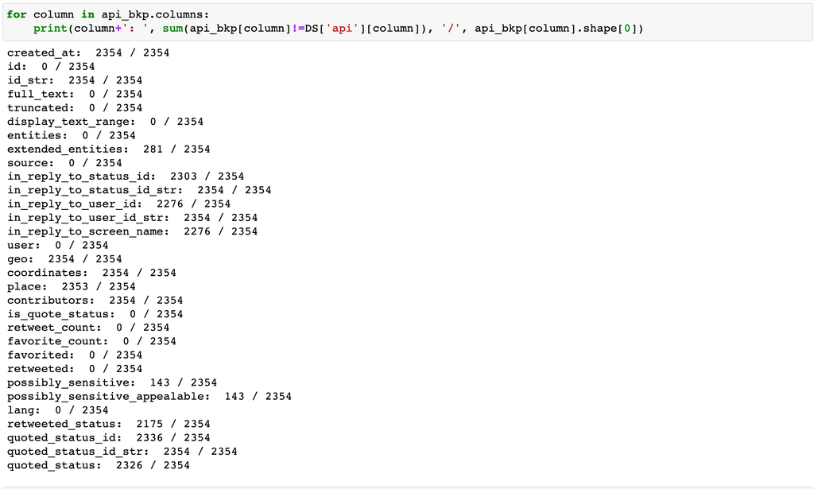

- Original Data

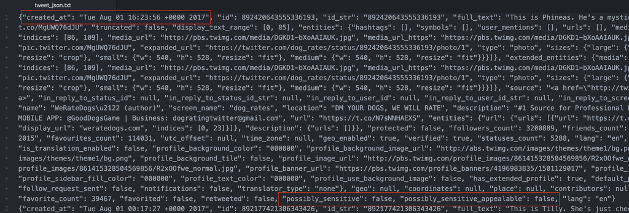

It looks like Pandas' import via `json.loads` processes the data in accordance with the original .json file.

This issue should be investigated further.

However, we will not proceed further, for this lays out of the scope of this project.

### 2.3 Import Check for Image Predictions

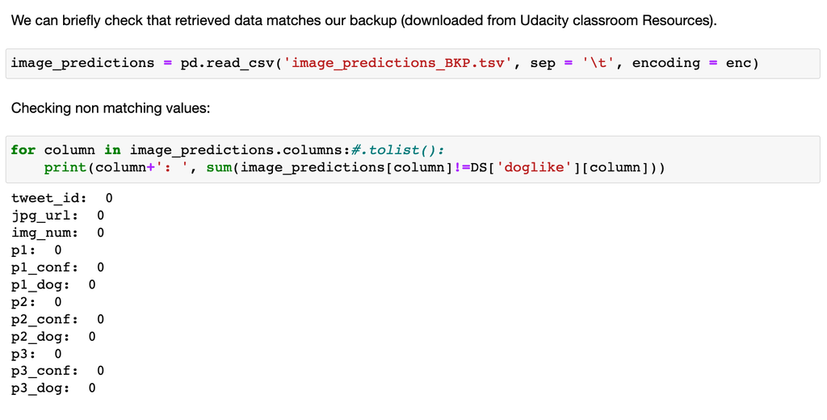

## 3 Assess

The programmatical assessment took place in full for the Twitter Archive, whereas it has been limited to the columns actually used of the API data (`retweet_count`, and `favorite_count` for tweet IDs contained in the trimmed version of the Enhanced Twitter Archive).

For `image_predictions` we posed more focus on the relation between tweets and image links, and between breed kind and its detection in the `p1_dog`, `p2_dog`, `p3_dog` columns.

## 4 Clean

We have cleaned each issue identified during the assessment stage by iteratively defining the issue, coding the related cleaning process and testing the result.

We have removed columns containing 'NaN's only.

While tackling issue 'Cleanness - 6, 7', we have integrated numerators from tweet text and corrected float entries (handled with rounding). Numerators and denominators have been normalized.

In 'Cleanness - 8', we have removed wrong names, found other missing names, and integrated them. (Names found where the actual name was following the word 'named').

We mapped columns `doggo`, `floofer`, `pupper`, `puppo` into a new, unique column `dog_stages`. This latter contains stages of dogs in each tweet. In doing so, we can keep the same observational unit (tweets) in the master data frame.

## 5 Store, Analyze, and Visualize

We counted ratings per day and derived average rating values per `weekday` from the timestamp directly by leveraging on Pandas' datetime methods. We have visually analyzed a graph of the daily tweet frequeny over time.